# visualization

Yuchen Zheng

12/10/2021

```r
library(tidyverse)
library(ggplot2)
library(patchwork)

theme_set(theme_minimal() + theme(legend.position = "bottom"))

knitr::opts_chunk$set(
  echo = TRUE,
  warning = FALSE,
  fig.width = 10,
  fig.height = 6,
  out.width = "90%"
)
```

## Visualization

```r
# read in data for visualization
taxi_df = read_csv("./data_vis/taxi_vis.csv")
bike_df = read_csv("./data_vis/bike_vis.csv")

# read in sample data
taxi_df_sample =
  read_csv("./data_vis/taxi_sample.csv") %>%
  mutate(time_of_day = factor(time_of_day, levels = c("early_morning", "rush_hour_am", "midday", "rush_hour_pm", "evening")),
         season = factor(season, levels = c("spring", "summer", "fall", "winter")))

bike_df_sample =
  read_csv("./data_vis/bike_sample.csv") %>%
  mutate(time_of_day = factor(time_of_day, levels = c("early_morning", "rush_hour_am", "midday", "rush_hour_pm", "evening")),
         season = factor(season, levels = c("spring", "summer", "fall", "winter")))

subway_df_sample =
  read_csv("./data_vis/subway_sample.csv") %>%
  mutate(time_of_day = factor(time_of_day, levels = c("early_morning", "rush_hour_am", "midday", "rush_hour_pm", "evening")),
         season = factor(season, levels = c("spring", "summer", "fall", "winter")))
```

## Most Frequent Origin - Destination Pairs

Looking at the most frequent origin-destination pairs in our dataset, we can see which areas in Manhattan people prefer getting around by taxi and which area in Manhattan people prefer getting around by bike.

### Taxi

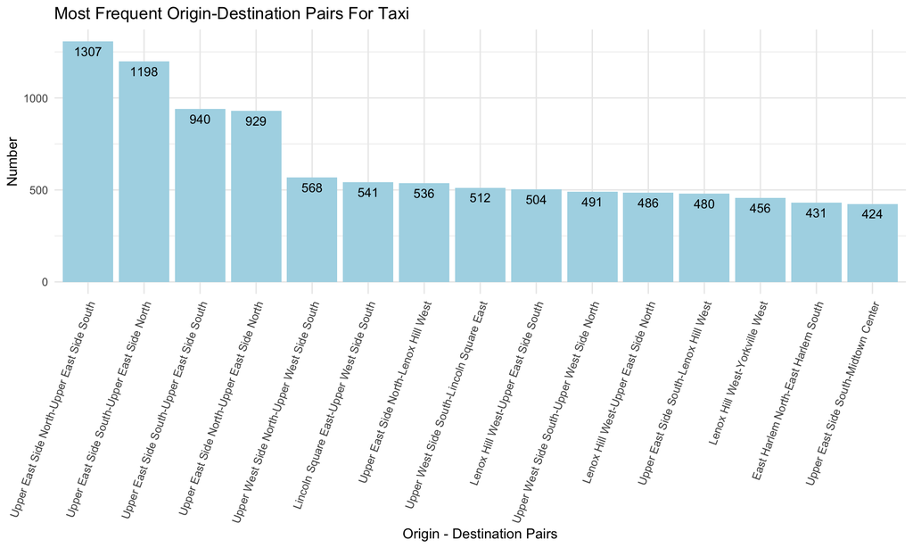

```r
taxi_df %>%
  mutate(loc_pair = fct_infreq(loc_pair)) %>%
  group_by(loc_pair) %>%
  summarize(total = n()) %>%
  arrange(desc(total)) %>%
  top_n(15) %>%
  ggplot(aes(x = loc_pair, y = total)) +
  geom_bar(stat = "identity" , fill = "lightblue")+
  theme(axis.text.x = element_text(angle = 70, vjust = 1, hjust=1)) +
  geom_text(aes(label=total), vjust=1.6, color="black", size=3.5) +
  labs(title = "Most Frequent Origin-Destination Pairs For Taxi", x = "Origin - Destination Pairs", y = "Number")
```

From this barplot we can see that the most frequent origin-destination pairs are located in the upper east side and in the upper west side.

## Bike

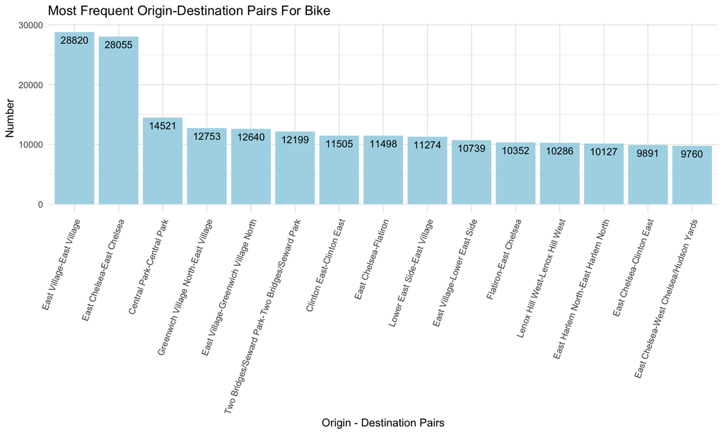

```r
bike_df %>%
  mutate(loc_pair = fct_infreq(loc_pair)) %>%
  group_by(loc_pair) %>%
  summarize(total = n()) %>%
  arrange(desc(total)) %>%
  top_n(15) %>%
  ggplot(aes(x = loc_pair, y = total)) +
  geom_bar(stat = "identity" , fill = "lightblue")+
  theme(axis.text.x = element_text(angle = 70, vjust = 1, hjust=1)) +
  geom_text(aes(label=total), vjust=1.6, color="black", size=3.5) +
  labs(title = "Most Frequent Origin-Destination Pairs For Bike", x = "Origin - Destination Pairs", y = "Number")
```

From this barplot we can see that the most frequent origin-destination pairs for bike are located in East Village, East Chelsea and Central Park.

To get a general understanding of the travel time and the travel velocity of each type of transportation, we made heatmaps and boxplots to show travel time and velocity during different time periods of the day and across seasons.

## Taxi Travel Time vs. Bike Travel Time

```r
# taxi heatmap for duration
hp1 =
  taxi_df_sample %>%
  group_by(season, time_of_day) %>%
  mutate(grp_mean = mean(duration)) %>%
  select(season, time_of_day, grp_mean) %>%
  ggplot(aes(season, time_of_day)) +
  geom_tile(aes(fill = grp_mean), color = "white", lwd = 0.8, linetype = 1) +
  scale_fill_gradient(low = "lightblue", high = "black", limits = c(8, 16)) +
  geom_text(aes(label = round(grp_mean, digits = 2), color = "white")) +
  labs(title = "Duration of Taxi Heatmap", x = "Season", y ="Time of Day", fill = "Mean Duration (mins)")
```

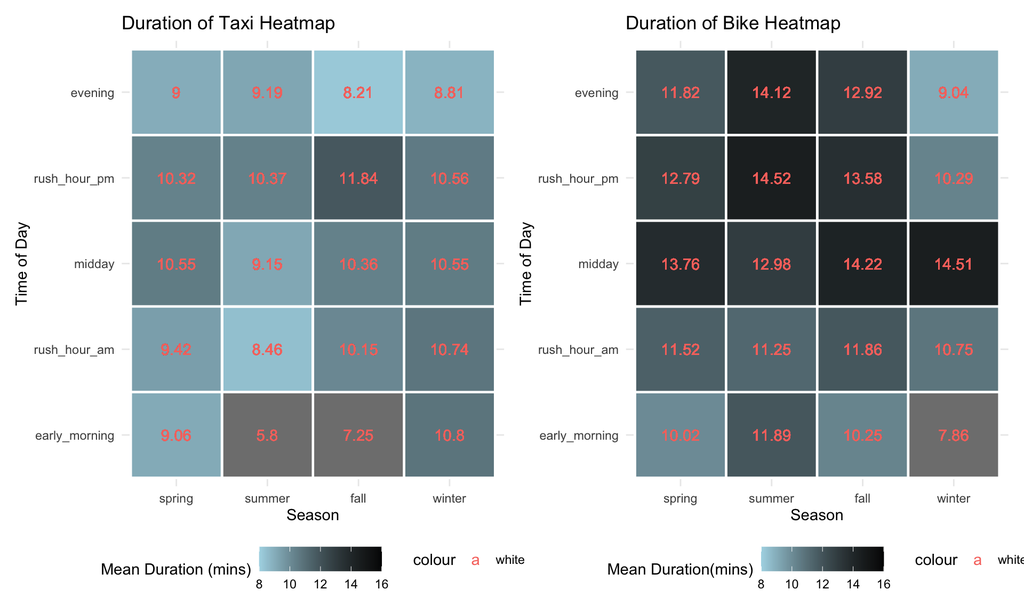

```r
# bike heatmap for duration
hp2 =
  bike_df_sample %>%
  group_by(season, time_of_day) %>%
  mutate(grp_mean = mean(duration)) %>%
  select(season, time_of_day, grp_mean) %>%
  ggplot(aes(season, time_of_day)) +
  geom_tile(aes(fill = grp_mean), color = "white", lwd = 0.8, linetype = 1) +
  scale_fill_gradient(low = "lightblue", high = "black", limits = c(8, 16)) +
  geom_text(aes(label = round(grp_mean, digits = 2), color = "white")) +
  labs(title = "Duration of Bike Heatmap", x = "Season", y ="Time of Day", fill = "Mean Duration(mins)")

hp1 + hp2
```

```r
# taxi heatmap for velocity
hp3 =
  taxi_df_sample %>%
  group_by(season, time_of_day) %>%
  mutate(grp_mean = mean(velocity)) %>%
  select(season, time_of_day, grp_mean) %>%
  ggplot(aes(season, time_of_day)) +
  geom_tile(aes(fill = grp_mean), color = "white", lwd = 0.8, linetype = 1) +
  scale_fill_gradient(low = "white", high = "red", limits = c(10, 27)) +
  geom_text(aes(label = round(grp_mean, digits = 2))) +
  labs(title = "Velocity of Taxi Heatmap", x = "Season", y ="Time of Day", fill = "Mean Velocity(km/h)")
```

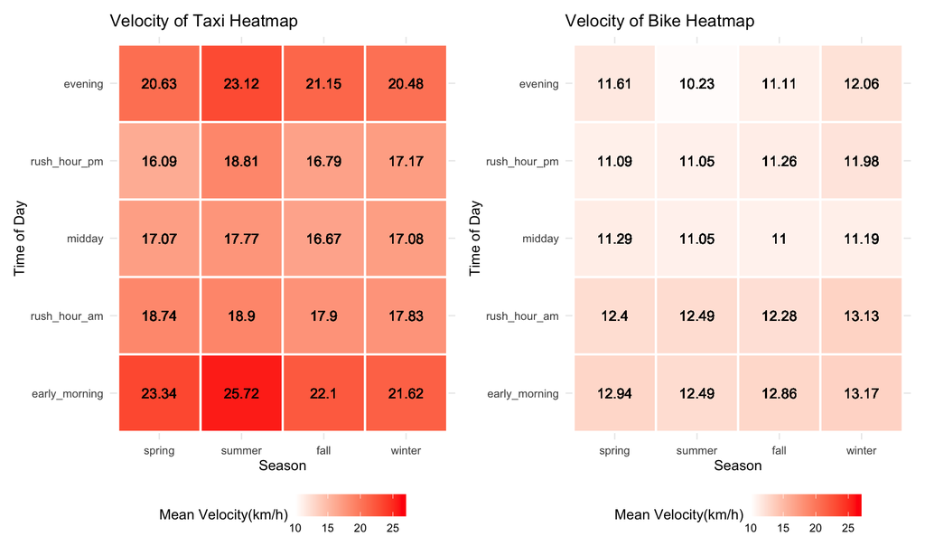

```r
# bike heatmap for velocity
hp4 =
  bike_df_sample %>%
  group_by(season, time_of_day) %>%
  mutate(grp_mean = mean(velocity)) %>%
  select(season, time_of_day, grp_mean) %>%
  ggplot(aes(season, time_of_day)) +
  geom_tile(aes(fill = grp_mean), color = "white", lwd = 0.8, linetype = 1) +
  scale_fill_gradient(low = "white", high = "red", limits = c(10, 27)) +
  geom_text(aes(label = round(grp_mean, digits = 2))) +
  labs(title = "Velocity of Bike Heatmap", x = "Season", y ="Time of Day", fill = "Mean Velocity(km/h)")

hp3 + hp4
```

```r
# combine taxi bike, subway datasets to make boxplot
comb_df = bind_rows(taxi_df_sample, bike_df_sample, subway_df_sample)
```

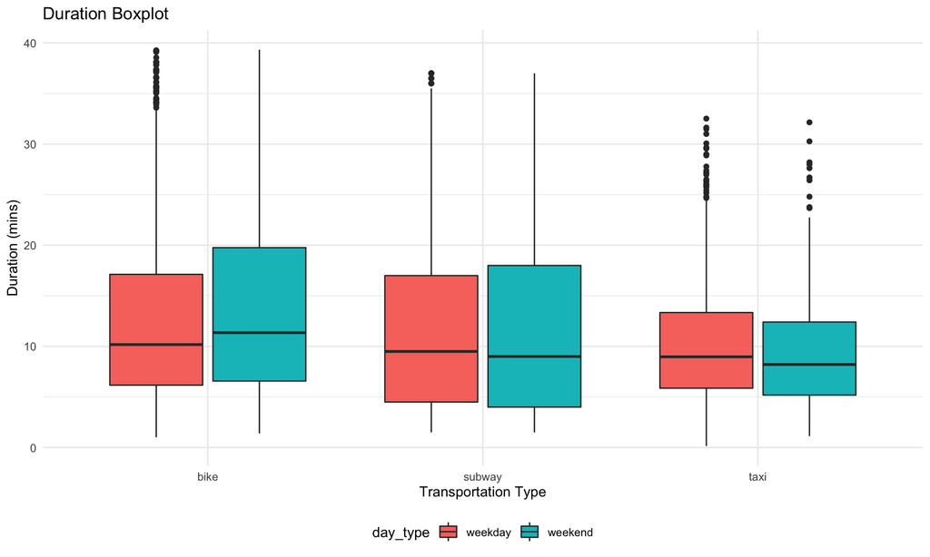

```r
comb_df %>%
  ggplot(aes(x = type, y = duration, fill = day_type)) +
  geom_boxplot() +
  labs(title = "Duration Boxplot", x = "Transportation Type", y = "Duration (mins)")
```

This duration boxplot compares the travel time on weekdays and weekends for each type of transportation. From this plot we can see that the travel time is greater on weekend for bike. The travel time seems to be similar for subway on both weekdays and weekend. The travel time for taxi is longer on weekdays.

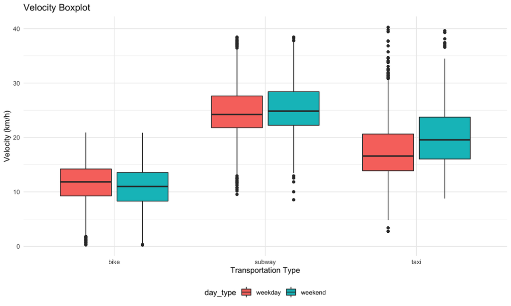

```r
comb_df %>%
  ggplot(aes(x = type, y = velocity, fill = day_type)) +
  geom_boxplot() +
  labs(title = "Velocity Boxplot", x = "Transportation Type", y = "Velocity (km/h)")
```

This velocity boxplot compares the travel velocity on weekdays and weekends for each type of transportation. From this plot we can see that the velocities for subway on both weekdays and weekend are the greatest and they are similar across the week. Taxi travels faster on the weekend and bike travels faster on weekdays.